# Lecture 3: The Spatial Dimension - Economic Geography and Regional System

Daniel S. Hain (dsh@business.aau.dk)

08 April, 2019

Loading some packages

```r
### Load packages
# Standard
library(tidyverse) # Collection of all the good stuff like dplyr, ggplot2 ect.
library(magrittr) # For extra-piping operators (eg. %<>%)
library(skimr) # Nice descriptives

# Network specific
library(tidygraph) # For tidy-style graph manipulation
library(igraph)
library(ggraph) # For ggplot2 style graph plotting
```

# 1 A closer look at the Chinese patenting activity

## 1.1 Loading and understanding the data structure

So, let’s start the fun. I for you extracted Chinese patents from our EPO [PATSTAT](https://www.epo.org/searching-for-patents/business/patstat.html) databases filed at either the EPO or the USTPO. I further provide you adittional data. Lets take a look:

```r
patents <- readRDS("../input/CN_patent.rds")
inventors <- readRDS("../input/CN_inventor.rds") %>% filter(str_detect(city, "china")) %>% mutate(city = city %>% str_remove("\\,.*"))
el.pat_inv <- readRDS("../input/CN_el_inventor_patent.rds")
el.pat_tech <- readRDS("../input/CN_el_patent_field.rds")
```

```r
patents %>% glimpse()
```

```
## Observations: 66,266
## Variables: 5
## $ appln_id            <int> 53568634, 53699173, 15765821, 48003535, 32...
## $ appln_filing_year   <int> 2001, 2001, 2000, 2002, 2010, 2003, 2002, ...
## $ docdb_family_size   <int> 6, 13, 5, 7, 20, 11, 5, 5, 4, 8, 4, 10, 4,...
## $ nb_citing_docdb_fam <int> 14, 73, 43, 27, 81, 57, 7, 17, 1, 5, 29, 1...
## $ nb_inventors        <int> 5, 5, 5, 1, 4, 2, 1, 1, 4, 6, 5, 1, 1, 2, ...
```

This main dataset contains all Patents in the 2000-2015 period with Chinese inventors, filed at the USTPO or EPO. I only included priority (earliest) patent applications which got granted up to now. We have the following variables:

- `appln_id`: PATSTAT id, unique identifier of patent application
- `appln_filing_year`: Filing year of first priority
- `docdb_family_size`: Size of the (simple) patent family
- `nb_citing_docdb_fam`: Number of citations recieved by the patent family
- `nb_inventors`: Number of inventors

```r
patents %>% summary()
```

```
##     appln_id         appln_filing_year docdb_family_size
##  Min.   :     1790   Min.   :2000      Min.   :  1.000
##  1st Qu.:311601087   1st Qu.:2009      1st Qu.:  2.000
##  Median :380232212   Median :2011      Median :  3.000
##  Mean   :325255889   Mean   :2011      Mean   :  3.959
##  3rd Qu.:426173726   3rd Qu.:2013      3rd Qu.:  5.000
##  Max.   :497361534   Max.   :2015      Max.   :217.000
##  nb_citing_docdb_fam  nb_inventors
##  Min.   :  0.000     Min.   : 1.00
##  1st Qu.:  1.000     1st Qu.: 2.00
##  Median :  4.000     Median : 3.00
##  Mean   :  7.756     Mean   : 3.16
##  3rd Qu.:  9.000     3rd Qu.: 4.00
##  Max.   :421.000     Max.   :31.00
```

```r
inventors %>% glimpse()
```

```
## Observations: 82,678
## Variables: 5
## $ person_id <int> 4932, 5805, 5960, 6375, 6377, 6378, 6396, 6745, 6757...
## $ psn_name  <chr> "XU, KAIHUA", "WANG, WEI", "DU, BIN", "TIAN, GUANGHU...
## $ city      <chr> "shenzhen", "shenzhen", "shenzhen", "shanghai", "sha...
## $ lon       <dbl> 114.06, 114.06, 114.06, 121.47, 121.47, 121.47, 117....
## $ lat       <dbl> 22.54, 22.54, 22.54, 31.23, 31.23, 31.23, 36.65, 22....
```

This are all Chinese inventors indicated on the selected patents. Foreign inventors are excluded. We enriched this data with an geocoding exercise. It up to now managed to match only around 75% of all inventors, new and better version in the making.

- `person_id`: Unique inventor identifyer
- `psn_name`: OECD HAN (harminized) inventor name
- `city`: Inventors city, extracted with own adressparsing (not 100%)
- `lon`: City longitude (own geocoding, not 100%)
- `lat`: City lattitude (own geocoding, not 100%)

```r
inventors %>% summary()
```

```
##    person_id          psn_name             city                lon
##  Min.   :    4932   Length:82678       Length:82678       Min.   : 81.87
##  1st Qu.:11471092   Class :character   Class :character   1st Qu.:114.06
##  Median :47219512   Mode  :character   Mode  :character   Median :116.41
##  Mean   :33327317                                         Mean   :116.56
##  3rd Qu.:49867186                                         3rd Qu.:120.16
##  Max.   :56987430                                         Max.   :140.51
##       lat
##  Min.   :18.80
##  1st Qu.:22.54
##  Median :31.23
##  Mean   :30.60
##  3rd Qu.:39.90
##  Max.   :47.35
```

```r
el.pat_inv %>% glimpse()
```

```
## Observations: 168,559
## Variables: 3
## $ appln_id    <int> 1790, 1790, 1790, 1800, 1800, 1800, 1800, 1815, 18...
## $ person_id   <int> 56646827, 56799439, 56629287, 55622980, 49131108, ...
## $ invt_seq_nr <int> 1, 2, 3, 1, 2, 3, 4, 1, 2, 3, 1, 1, 2, 3, 4, 5, 6,...
```

Edgeliste, matching patents with inventors.

```r
el.pat_tech %>% glimpse()
```

```
## Observations: 103,096
## Variables: 3
## $ appln_id       <int> 1790, 1790, 1800, 1815, 1823, 1823, 1823, 2052,...
## $ techn_field_nr <int> 3, 4, 3, 3, 20, 23, 24, 4, 3, 2, 4, 3, 16, 17, ...
## $ weight         <dbl> 0.666667, 0.333333, 1.000000, 1.000000, 0.20000...
```

Edgeliste, matching patent with technology field.

Technology fields represent a higher level of aggregation compared to IPC classes, and classify technologies into 35 fields. Patents can be assigned to multiple fields simultaneously. Since the raw number is not very informative, lets get a field description.

```r
field_names <- read_csv("../input/ipc_technology.csv") %>%
  select(field_nr, sector, field_name) %>%
  distinct(field_nr, .keep_all = TRUE) %>%
  mutate(field_nr = field_nr) %>%
  arrange(field_nr)
```

```r
field_names %>% distinct(field_name)
```

| field_name |
| --- |
| Electrical machinery, apparatus, energy |
| Audio-visual technology |
| Telecommunications |
| Digital communication |
| Basic communication processes |
| Computer technology |
| IT methods for management |
| Semiconductors |
| Optics |
| Measurement |

[output cut: 25 more lines]

On a even higher level, these fields are classified in 5 sectors.

```r
field_names %>% distinct(sector)
```

| sector |
| --- |
| Electrical engineering |
| Instruments |
| Chemistry |
| Mechanical engineering |
| Other fields |

## 1.2 First investigation

Alright, lets take a first look at the development of chinese patents over time.

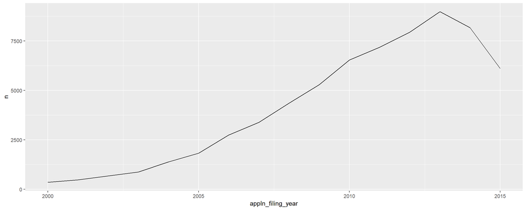

```r
patents %>%
  group_by(appln_filing_year) %>%
  summarise(n = n()) %>%
  ggplot(aes(x = appln_filing_year, y = n)) +
  geom_line()
```

Ok, we see that patent applications sharply increased over time… We see somewhat a decline after 2013, but I would suggest the reason to be a lag in reporting.

Lets look at the sectoral split.

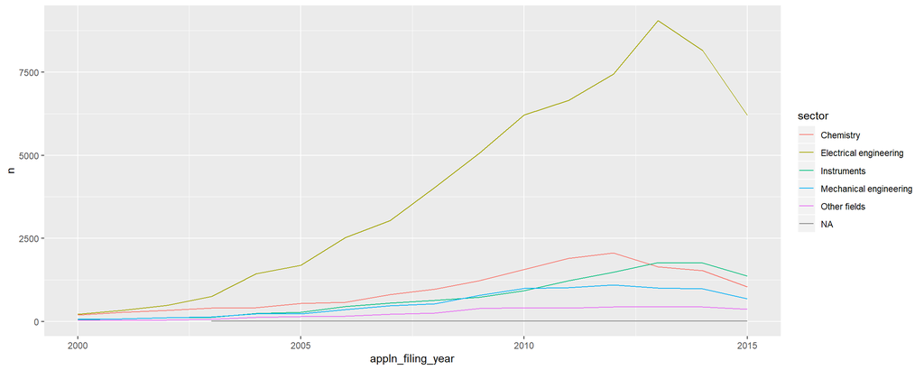

```r
patents.field <- patents %>%
  left_join(el.pat_tech, by = "appln_id") %>%
  left_join(field_names, by = c("techn_field_nr" = "field_nr"))

patents.field %>%
  group_by(appln_filing_year, sector) %>%
  summarise(n = n()) %>%
  ggplot(aes(x = appln_filing_year, y = n, col = sector)) +
  geom_line()
```

It seems as if electrical engineering leads by far…

# 2 The Geography of Chinese patents

## 2.1 Data munging

First, we will create a list of unique cities including their geolocation.

```r
cities.geo <- inventors %>%
  distinct(city, .keep_all = TRUE) %>%
  select(city, lon, lat)
```

Now, lets create a dataset of patents including their applicants and geolocation. To make it easier, we will only look at the first applicants in the `invt_seq_nr`, and discard the rest (alternatively, we could fractionalize them).

```r
reg.pat <- el.pat_inv %>%
  arrange(appln_id, invt_seq_nr) %>%
  distinct(appln_id, .keep_all = TRUE) %>%
  left_join(inventors %>% select(person_id, city), by = "person_id") %>%
  left_join(patents %>% select(appln_id, appln_filing_year, nb_citing_docdb_fam), by = "appln_id") %>%
  select(-invt_seq_nr, person_id)
```

## 2.2 Top patenting cities

Lets see which cities account for the most patents. Any guesses?

```r
top.cities <- reg.pat %>%
  group_by(city) %>%
  summarise(n = n(),
            n.cit = sum(nb_citing_docdb_fam)) %>%
  arrange(desc(n)) %>%
  top_n(10, n)

top.cities
```

| city | n | n.cit |
| --- | --- | --- |
| shenzhen | 22242 | 148429 |
| beijing | 18528 | 176074 |
| shanghai | 11633 | 89441 |
| hangzhou | 1444 | 12497 |
| nanjing | 1029 | 8126 |
| kunshan | 1001 | 7749 |
| guangzhou | 846 | 5278 |
| wuhan | 753 | 4642 |
| suzhou | 732 | 9851 |
| chengdu | 715 | 4773 |

## 2.3 Activity over time

Lets see how the cities developed over time.

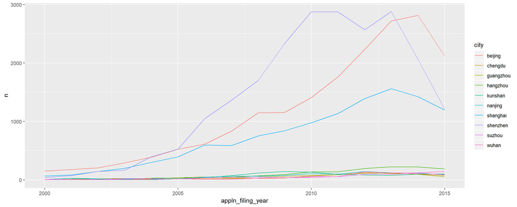

```r
reg.pat %>%
  group_by(city, appln_filing_year) %>%
  summarise(n = n(),
            n.cit = sum(nb_citing_docdb_fam)) %>%
  arrange(desc(n)) %>%
  filter(city %in% (top.cities %>% pull(city))) %>%
  ggplot(aes(x = appln_filing_year, y = n, col = city)) +
  geom_line()
```

## 2.4 Geoplotting

Lets see how that on aggregate looks on a map. Therefore, we first need some map-data for china. Usually I use the excellent `ggmap` package for that, but it uses a google back-end and needs a developer-id (problematic here in China). I figured out that Baidu has an almost equal package, but didnt figure out how to get an API key there in short time. Therefore, we will use some simple offline map data.

```r
library(mapdata) # with china map
map <- borders(database = "world", regions = "China")
```

There we go, that’s how it looks.

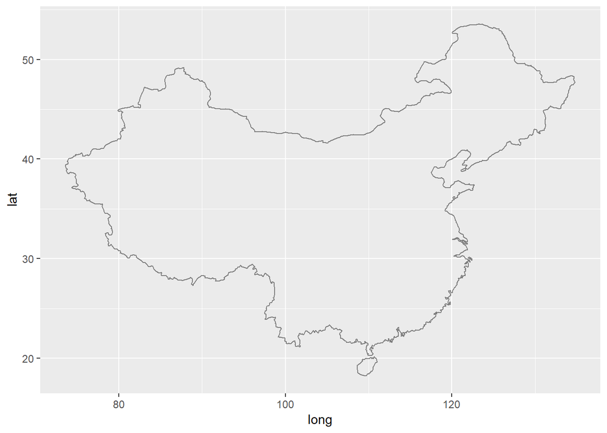

```r
ggplot() +
  map
```

Now, we just need to plot the cities in, scaled by patenting activity.

```r
reg.pat.agg <- reg.pat %>%
  group_by(city) %>%
  summarise(n = n(),
            n.cit = sum(nb_citing_docdb_fam)) %>%
  left_join(cities.geo, by = "city") %>%
  drop_na()
```

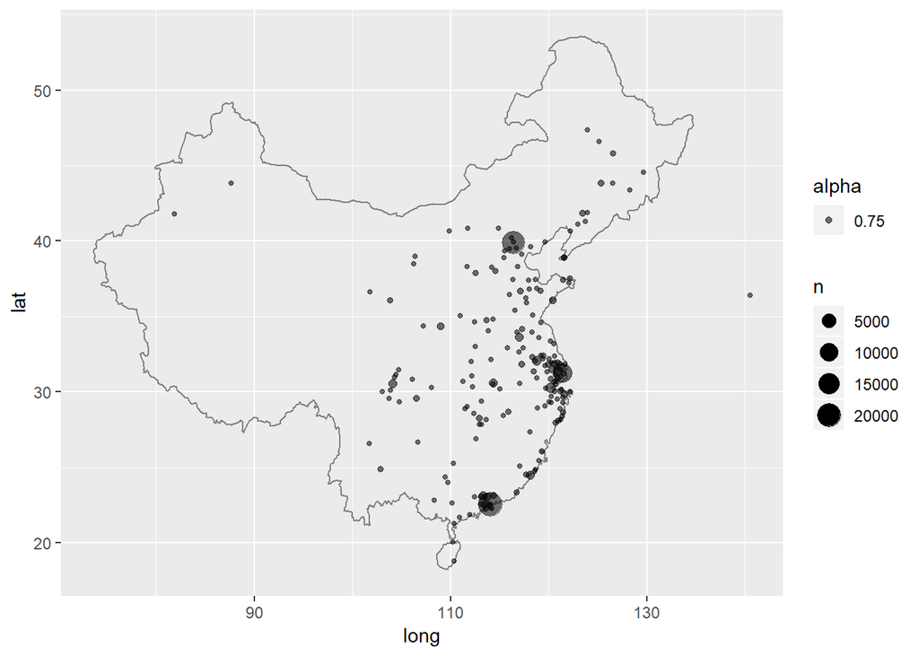

```r
ggplot() +
  map +
  geom_point(data = reg.pat.agg,
             aes(x = lon, y = lat, size = n, alpha = 0.75))
```

Ok, we can even do better, and add a nice density layer on top.

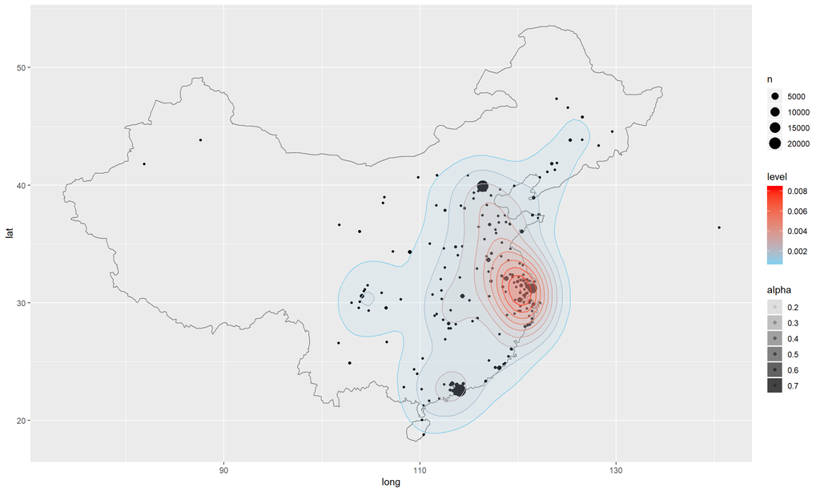

```r
ggplot() +
  map +
  geom_point(data = reg.pat.agg,
             aes(x = lon, y = lat, size = n, alpha = 0.75)) +
  stat_density2d(data = reg.pat.agg,
                 aes(x = lon, y = lat, fill = ..level.. , alpha = 0.2, col = ..level..), size = 0.5, bins = 10, geom = "polygon") +
  scale_fill_gradient(low = "skyblue", high = "red") +
  scale_color_gradient(low = "skyblue", high = "red")
```

Neath, isn’t it? Here we really see where Chinese patenting activity agglomorates.

# 3 Economic complexity of Chinese patenting activity

Let’s not take a look at the complexity of Chinese patenting activity.

We will here use some neath functions from the`R` package `EconGeo`. Its only on github, so we have to install it from there.

```r
#devtools::install_github("PABalland/EconGeo", force = T)
library(EconGeo)
```

## 3.1 Data munging

First, here we will need to create some big matrices, therefore I will here already define a little helper function which takes an edgelist as input and produces really efficient a sparse `M[i,j]` 2-mode matrix.

```r
## Helper function
create_sparse_matrix <- function(i.input, j.input){
  require(Matrix)
  mat <- spMatrix(nrow = i.input %>% n_distinct(),
                  ncol = j.input %>% n_distinct(),
                  i = i.input %>% factor() %>% as.numeric(),
                  j = j.input %>% factor() %>% as.numeric(),
                  x = rep(1, i.input %>% length() ) )

  row.names(mat) <- i.input %>% factor() %>% levels()
  colnames(mat) <- j.input %>% factor() %>% levels()
  return(mat)
}
```

Now, we will create this sparse matrix between patents and their associated technology classes.

```r
mat.tech <- create_sparse_matrix(i = el.pat_tech %>% pull(appln_id),
                                 j = el.pat_tech %>% pull(techn_field_nr))
```

We can do that very efficiently with the `crossprod()` and `tcrossprod()` function of the `Matrix` package.

```r
mat.tech %<>%
  crossprod() %>%
  as.matrix()

#mat.pat <- mat.tech %>% tcrossprod() %>% as.matrix() # Would create a patent matrix based on shared IPC classes (Not a good idea here)
```

This matrix can be used for the `relatedness()` function to transform the co-occurence adjacency matrix to a similarity matrix. This function computes the relatedness (Hidalgo et al., 2007; Boschma et al., 2015; Balland, 2016) between entities (industries, technologies, . . . ) from their co-occurrence (adjacency) matrix. Different normalization procedures are proposed following van Eck and Waltman (2009): association strength, cosine, Jaccard, and an adapted version of the association strength (probability index). I here choose the cosine similarity, since it is not so sensitive to scale.

```r
mat.tech %<>%
  relatedness(method = "cosine")
```

## 3.2 The Chinese Technology Space

With this matrix, we can now create the Chinese “Technology Space” a’la Hidalgo & Hausmann (2007). Here we create a network of technology fields. I will delete below average weights to create some sparsity, and calculate the eigenvector centrality. I will here use the Eigenvector centrality as an easy proxi for technological complexity.

```r
library(tidygraph)

g.tech <- mat.tech %>% as_tbl_graph(directed = FALSE) %N>%
  left_join(field_names %>% mutate(field_nr = field_nr %>% as.character()), by = c("name" = "field_nr")) %>%
  mutate(dgr = centrality_eigen(weights = weight)) %E>%
  filter(weight >= mean(weight))

g.tech
```

```
## # A tbl_graph: 35 nodes and 177 edges
## #
## # An undirected simple graph with 1 component
## #
## # Edge Data: 177 x 3 (active)
##    from    to weight
##   <int> <int>  <dbl>
## 1     1     2 0.124
## 2     1     3 0.0316
## 3     1     5 0.0652
## 4     1     6 0.0583
## 5     1     8 0.0904
## 6     1     9 0.131
## # ... with 171 more rows
## #
## # Node Data: 35 x 4
##   name  sector                 field_name                               dgr
##   <chr> <chr>                  <chr>                                  <dbl>
## 1 1     Electrical engineering Electrical machinery, apparatus, ener~ 0.731
## 2 2     Electrical engineering Audio-visual technology                0.895
## 3 3     Electrical engineering Telecommunications                     0.825
## # ... with 32 more rows
```

We will straight away visualize it as a network. We scale the nodes by their centrality, and color them by their higher level tech-sector.

In order to be able to reproduce the same node position in comparative graphs lateron, we will first save the node layout (classical fruchterman-reingold layout).

```r
coords.tech <- g.tech %>% layout.fruchterman.reingold() %>% as_tibble()
colnames(coords.tech) <- c("x", "y")
```

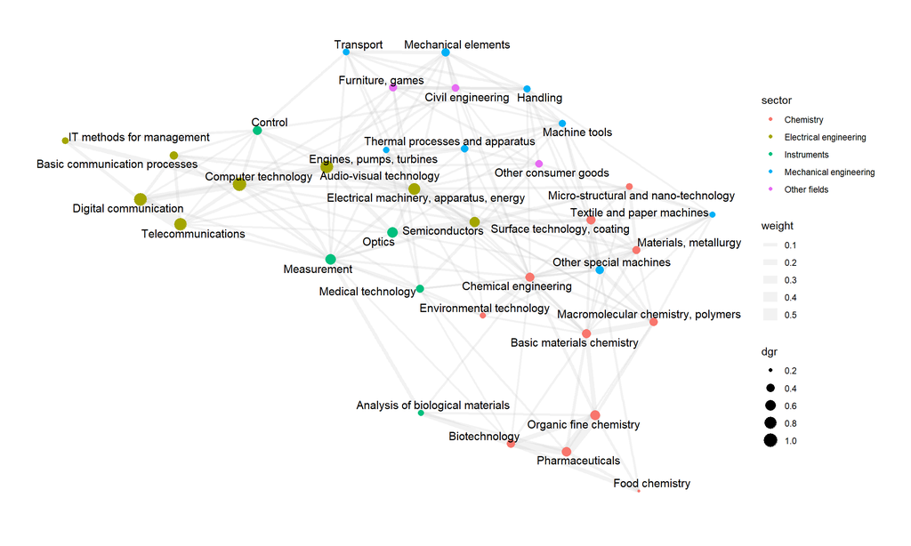

```r
library(ggraph)
g.tech %E>%
  ggraph(layout = "manual", node.positions = coords.tech) +
  geom_edge_link(aes(width = weight), alpha = 0.2, colour = "grey") +
  geom_node_point(aes(colour = sector, size = dgr)) +
  geom_node_text(aes(label = field_name), size = 4, repel = TRUE) +
  theme_graph()
```

Lets see which tech-field is the most central (complex) one:

```r
g.tech %N>%
  arrange(desc(dgr)) %>%
  as_tibble() %>%
  slice(1:10)
```

| name | sector | field_name | dgr |
| --- | --- | --- | --- |
| 6 | Electrical engineering | Computer technology | 1.0000000 |
| 4 | Electrical engineering | Digital communication | 0.8964893 |
| 2 | Electrical engineering | Audio-visual technology | 0.8951385 |
| 3 | Electrical engineering | Telecommunications | 0.8247798 |
| 1 | Electrical engineering | Electrical machinery, apparatus, energy | 0.7314700 |
| 9 | Instruments | Optics | 0.6038599 |
| 10 | Instruments | Measurement | 0.5933025 |
| 8 | Electrical engineering | Semiconductors | 0.5570694 |
| 14 | Chemistry | Organic fine chemistry | 0.5246693 |
| 16 | Chemistry | Pharmaceuticals | 0.4795009 |

And the least one…

```r
g.tech %N>%
  arrange(dgr) %>%
  as_tibble() %>%
  slice(1:10)
```

| name | sector | field_name | dgr |
| --- | --- | --- | --- |
| 18 | Chemistry | Food chemistry | 0.1947224 |
| 28 | Mechanical engineering | Textile and paper machines | 0.2599749 |
| 24 | Chemistry | Environmental technology | 0.2711145 |
| 11 | Instruments | Analysis of biological materials | 0.2716099 |
| 27 | Mechanical engineering | Engines, pumps, turbines | 0.2912000 |
| 22 | Chemistry | Micro-structural and nano-technology | 0.3002927 |
| 32 | Mechanical engineering | Transport | 0.3067894 |
| 7 | Electrical engineering | IT methods for management | 0.3073732 |
| 25 | Mechanical engineering | Handling | 0.3264650 |
| 26 | Mechanical engineering | Machine tools | 0.3293354 |

Optimally, one would have created this space on world-data, and not only Chinese patents, though. Let’s, now that we know the overall space, take a look at city level specialization and complexity.

## 3.3 Specialization pattern of cities

We here first join our city level patent data with the technology fields. Since a patent can have multiple ones, we this time fractionalize it with a `field_weight`.

```r
reg.tech <- reg.pat %>%
  left_join(el.pat_tech %>% select(appln_id, techn_field_nr), by = "appln_id") %>%
  group_by(appln_id) %>%
  mutate(field_weight = 1 / n()) %>%
  ungroup()
```

```r
reg.tech %<>%
  group_by(city, techn_field_nr) %>%
  summarise(n_tech_reg = sum(field_weight)) %>%
  ungroup() %>%
  drop_na()
```

Now, we for the `EconGeo` package again have to transform it to a matrix. Again, we have to set the rownames, which are depreciated in the `tibble`

```r
mat.reg.tech <- reg.tech %>%
  arrange(techn_field_nr, city) %>%
  spread(key = techn_field_nr, value = n_tech_reg, fill = 0)

rownames(mat.reg.tech) <- mat.reg.tech %>% pull(city)

mat.reg.tech %<>% select(-city) %>%
  as.matrix() %>%
  round()
```

```r
reg.RCA <- mat.reg.tech %>% location.quotient(binary = TRUE) %>%
  as.data.frame() %>%
  rownames_to_column("city") %>%
  as_tibble() %>%
  gather(key = "tech_field", value = "RCA", -city) %>%
  arrange(city, tech_field)

reg.RCA %>% head()
```

| city | tech_field | RCA |
| --- | --- | --- |
| ürümqi | 1 | 0 |
| ürümqi | 10 | 0 |
| ürümqi | 11 | 0 |
| ürümqi | 12 | 0 |
| ürümqi | 13 | 0 |
| ürümqi | 14 | 1 |

The `Herfindahl()` function computes the Herfindahl index from regions - industries matrices from (incidence) regions - industries matrices. It is a measure of concentration. This index is also known as the Herfindahl-Hirschman index (Herfindahl, 1959; Hirschman, 1945).

```r
mat.reg.tech %>% Herfindahl() %>% as.data.frame() %>% rownames_to_column("city") %>% rename(HH = ".") %>% arrange(desc(HH))
```

| city | HH |
| --- | --- |
| bengbu | 1.00000000 |
| binzhou | 1.00000000 |
| dunhua | 1.00000000 |
| guanghan | 1.00000000 |
| haining | 1.00000000 |
| hedong district | 1.00000000 |
| jingmen | 1.00000000 |
| laiwu | 1.00000000 |
| lin'an | 1.00000000 |
| liuyang | 1.00000000 |

[output cut: 182 more lines]

Next, we can compute the Shannon entropy index (Shannon and Weaver, 1949; Frenken et al., 2007) from regions - industries matrices from (incidence) regions - industries matrices.

```r
mat.reg.tech %>% entropy() %>% as.data.frame() %>% rownames_to_column("city") %>% rename(SE = ".") %>% arrange(desc(SE))
```

| city | SE |
| --- | --- |
| guangzhou | 4.691 |
| suzhou | 4.615 |
| qingdao | 4.545 |
| changsha | 4.499 |
| nanjing | 4.497 |
| ningbo | 4.431 |
| wuhan | 4.416 |
| shanghai | 4.357 |
| dalian | 4.316 |
| wuxi | 4.299 |

[output cut: 182 more lines]

Now, finally, we can inspect where in the technology space different cities are specialized. We select some of interest.

```r
city_select <- c("beijing", "shanghai", "shenzhen")
```

In the following, I plot the technology-space and highlights in red the fields where the city has an RCA.

### 3.3.1 Beijing

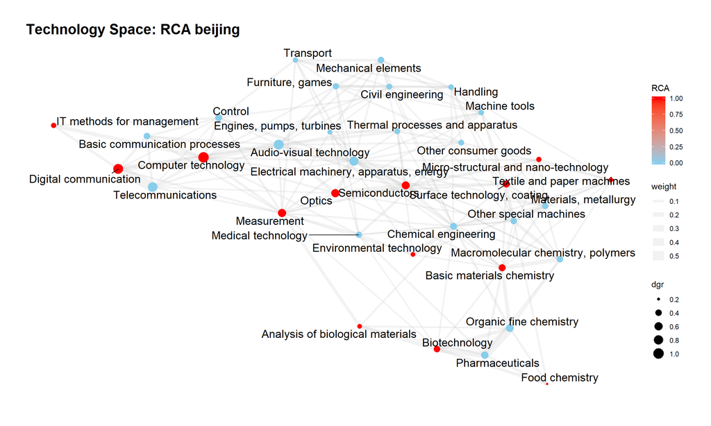

```r
i = 1
g.tech %N>%
  left_join(reg.RCA %>% filter(city == city_select[i]) %>% select(-city), by = c("name" = "tech_field")) %>%
  ggraph(layout = "manual", node.positions = coords.tech) +
  geom_edge_link(aes(width = weight), alpha = 0.2, colour = "grey") +
  geom_node_point(aes(colour = RCA, size = dgr)) +
  geom_node_text(aes(label = field_name), size = 5, repel = TRUE) +
  scale_color_gradient(low = "skyblue", high = "red") +
  theme_graph() +
  ggtitle(paste("Technology Space: RCA", city_select[i], sep = " "))
```

### 3.3.2 Shanghai

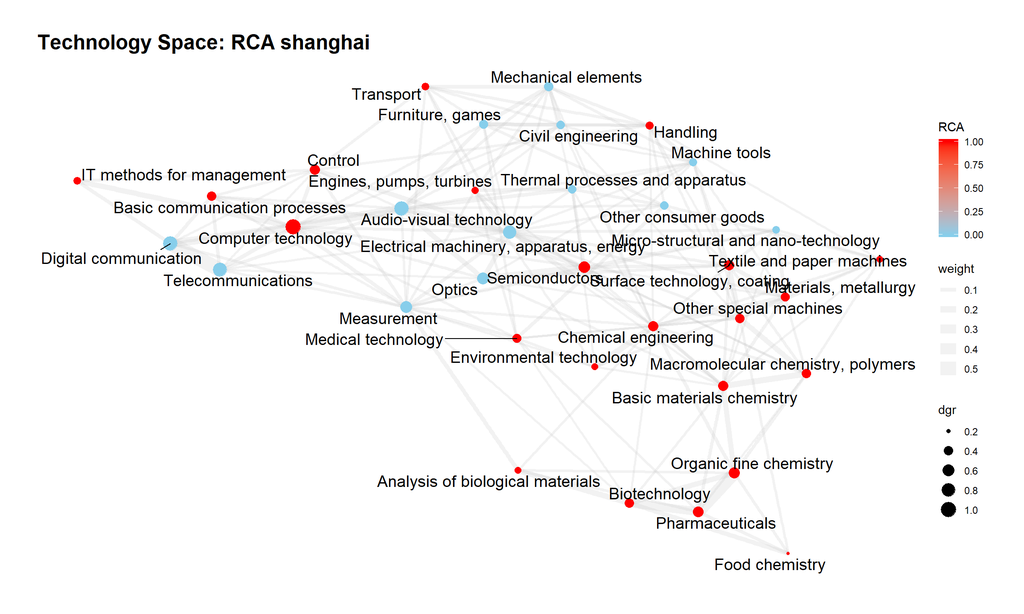

```r
i = 2
g.tech %N>%
  left_join(reg.RCA %>% filter(city == city_select[i]) %>% select(-city), by = c("name" = "tech_field")) %>%
  ggraph(layout = "manual", node.positions = coords.tech) +
  geom_edge_link(aes(width = weight), alpha = 0.2, colour = "grey") +
  geom_node_point(aes(colour = RCA, size = dgr)) +
  geom_node_text(aes(label = field_name), size = 5, repel = TRUE) +
  scale_color_gradient(low = "skyblue", high = "red") +
  theme_graph() +
  ggtitle(paste("Technology Space: RCA", city_select[i], sep = " "))
```

### 3.3.3 Shenzhen

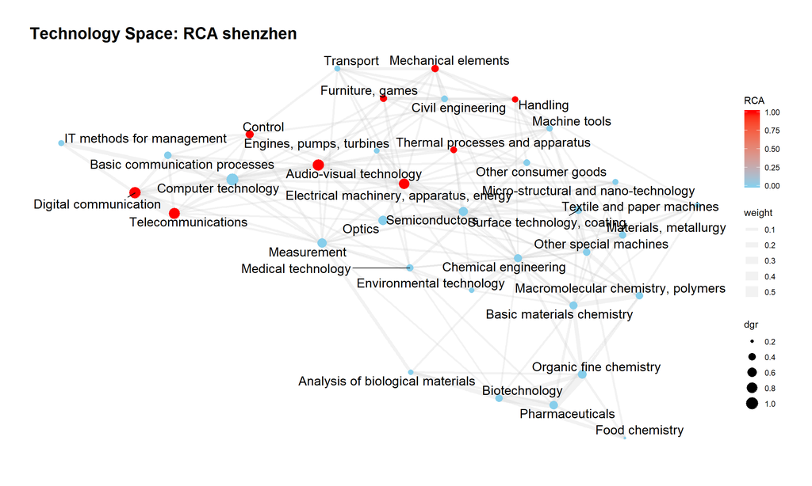

```r
i = 3
g.tech %N>%
  left_join(reg.RCA %>% filter(city == city_select[i]) %>% select(-city), by = c("name" = "tech_field")) %>%
  ggraph(layout = "manual", node.positions = coords.tech) +
  geom_edge_link(aes(width = weight), alpha = 0.2, colour = "grey") +
  geom_node_point(aes(colour = RCA, size = dgr)) +
  geom_node_text(aes(label = field_name), size = 5, repel = TRUE) +
  scale_color_gradient(low = "skyblue", high = "red") +
  theme_graph() +
  ggtitle(paste("Technology Space: RCA", city_select[i], sep = " "))
```

So, what differences do we see?